# Stan Mechanics

Justin Charbonneau

2019-08-29

# Acklowledgement

The following is an integration in STAN from JAGS. The excercises were taken from the post by Dr. Peter Rabinovitch who is the lead data scientist at Ario and Adjuct professor at the University of Ottawa. [Here](https://rstudio-pubs-static.s3.amazonaws.com/86915_2df0e9b3040b431396811b6a3b9030ce.html)

All following examples will use simulated data so you may reproduce the results.

# Introduction

You can interact with Stan in R using the RStan package. Alternatively, you can use Python using PyStan, but here I focus on using R.

Stan models are created using different blocks of code.

Required Blocks:

- data: Used to pass in the external data to the model and initialize the variables.
- parameters: Used to initialize the variables that the model is going to try and estimate.
- model: Contains the likelihood and the priors if you enter some. (By default, priors are set to have Uniform distribution)

Optional Blocks:

- functions
- transformed data
- transformed parameters
- generated quantities

Tip 1: Comments are done using `//` Tip 2: `Print()` statements may be used in the model block to print variables.

```r
library(dplyr); library(tidyr); library(rstan); library(ggplot2); library(rstan); library(broom);library(patchwork)
```

## Mean & Standard Deviation

For this example, we have two parameters that we want to estimate (mu and sigma). To keep this simple, we will stick with a uniform prior. But, a standard deviation cannot go bellow 0, so we must include this in our model definition.

Here we generate some data following the normal distribution.

```r
set.seed(2019)
n_obs <- 10
mu <- 10
sigma <- 5
x <- rnorm(n_obs, mu, sigma)
```

Next, we defined our model. We will only use the required blocks.

```r
model_01 <- "
data {
  int<lower=1> N;   // # of observations; constrained to be greater than 0
  vector[N] x;
}
parameters {
  real mu;          // Parameter's distribution saught
  real<lower=0> s;  // Parameter's distribution saught
}
model {
  target += normal_lpdf(x | mu, s);  // Likelihood
}
"
```

Stan takes in data as a named list. Here we defined the number of observations as `N` and the array of numbers as `x`. Then, we will sample some data points from the posterior distribution of the parameters and plot them.

To summarize your model, you may use `print()` or `plot()`. Here I used `plot()`.

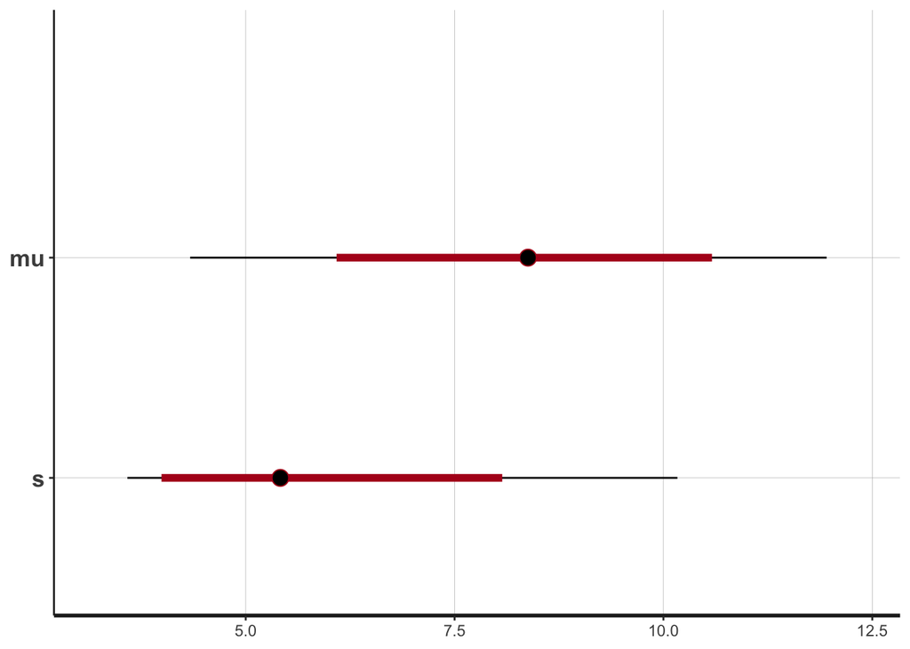

```r
data <- list(N = length(x),
             x = x)

fit <- sampling(stan_model(model_code=model_01), data = data, iter = 1000, chains = 2)

plot(fit)
```

The intervals are prety wide with the reason being the sample was too small. It is credible though, because the intervals cover 10 for mu and 5 for sigma. Lets re-run this example using 50 numbers instead of just 10. Here’s the output:

```r
set.seed(2019)
n_obs <- 50
mu <- 10
sigma <- 5
x <- rnorm(n_obs, mu, sigma)

data <- list(N = length(x),
             x = x)

fit <- sampling(stan_model(model_code=model_01), data = data, iter = 1000, chains = 2)
```

```
## ci_level: 0.8 (80% intervals)
```

```
## outer_level: 0.95 (95% intervals)
```

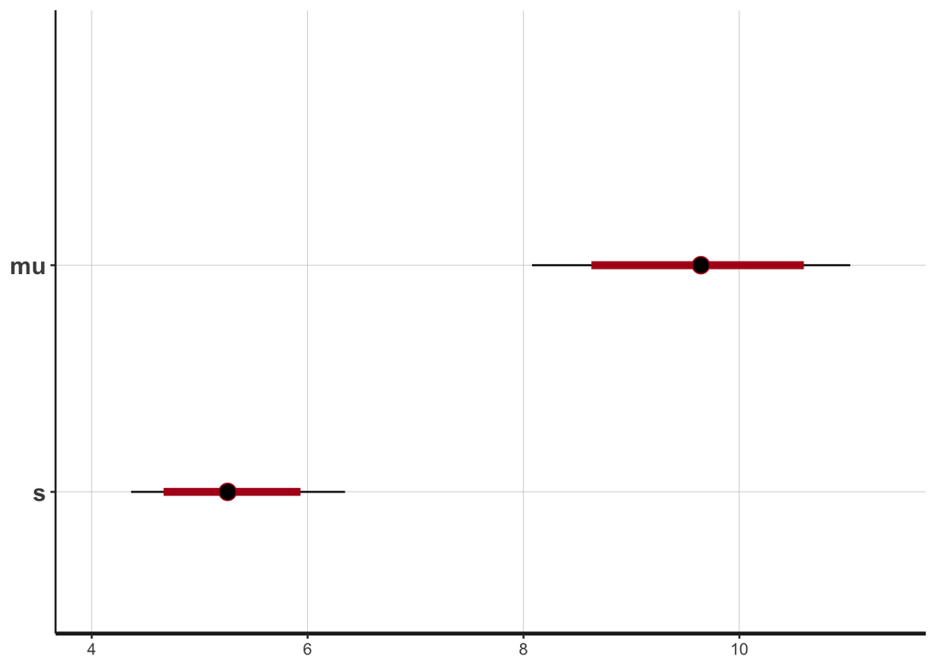

```r
plot(fit)
```

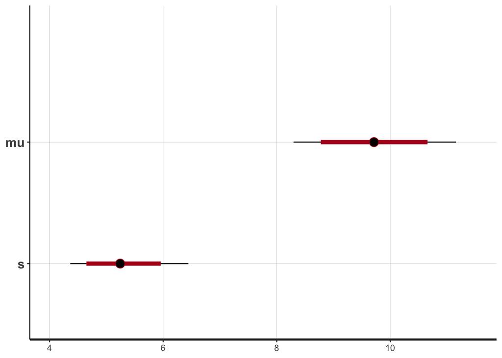

```r
model_01 <- "
data {
  int<lower=1> N;   // Number of observations; constrained to be greater than 1
  vector[N] x;
}
parameters {
  real mu;
  real<lower=0> s;  // Constrained to be greater than 0
}
model {
  // Likelihood
  target += normal_lpdf(x | mu, s);

  // Priors
  target += normal_lpdf(mu | 12, 4);
  target += normal_lpdf(s| 0, 10);
}
"

fit <- sampling(stan_model(model_code=model_01), data = data, iter = 1000, chains = 2)

plot(fit)
```

Slight improvement! From this, we could draw samples from the posterior distribution of the parameter by using the command `extract` and plot them.

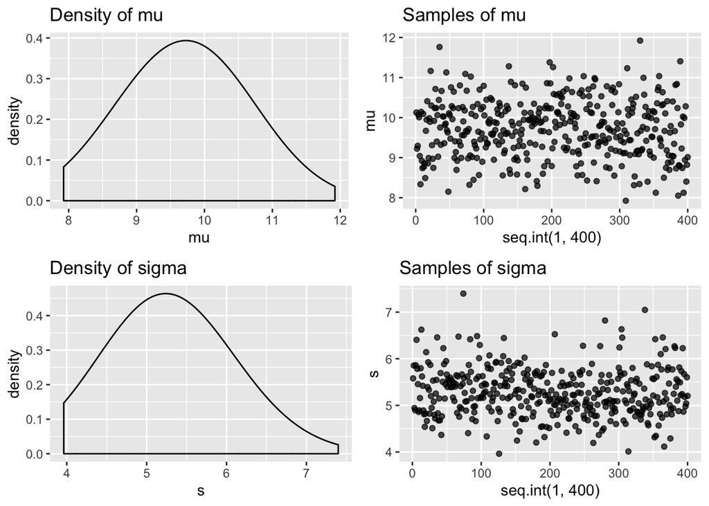

```r
samps <- fit %>% extract() %>% as_tibble() %>% sample_n(400)

p1 <- samps %>% ggplot(aes(mu))+geom_density(bw=.7)+labs(title="Density of mu")
p2 <- samps %>% ggplot(aes(x=seq.int(1,400),y=mu))+geom_point(alpha=0.7)+labs(title="Samples of mu")

p3 <- samps %>% ggplot(aes(s))+geom_density(bw=.7)+labs(title="Density of sigma")
p4 <- samps %>% ggplot(aes(x=seq.int(1,400),y=s))+geom_point(alpha=0.7)+labs(title="Samples of sigma")

(p1 + p2)/(p3 + p4)
```

## Mean & Standard Deviation Estimation with Outliers

Adding outliers will add variance to the model. To account for this, we use the student t distribution because it allows for the variation that we have in the data. Using the gaussian distribution would lead to a bad fit.

```r
set.seed(2019)
n <- 50
mux <- 10
s <- 3
x <- rnorm(n, mux, s)
x[23]<-50   # Adding outlier
x[35]<-60   # Adding outlier
x[45]<-55   # Adding outlier
```

Here we set the prior distribution for the other parameter nu to exponential from 0 to 29 because as the distribution approached 30 degrees of freedom, it converges to a normal distribution.

```r
model_02 <- "
data {
  int<lower=1> N;   // Number of samples and stop if smaller than 1
  vector[N] x;      // The actual data
}
parameters {
  real mu;                  // Posterior distribution sought
  real<lower=0> sigma;      // Posterior distribution sought
  real<lower=0> nu;         // Posterior distribution sought
}
model {
  target += student_t_lpdf(x | nu, mu, sigma);  // Likelihood

  target += normal_lpdf(mu | 10, 5);            // Prior
  target += normal_lpdf(sigma | 0, 10);         // Prior
  target += exponential_lpdf(nu | 1.0/29);      // Prior
}
"
```

```r
data_02 <- list(N = n,
             x = x)

fit_02 <- sampling(stan_model(model_code=model_02), data = data_02, iter = 2000, chains = 2, cores = 2)
```

Taking a quick look at the output …

```r
print(fit_02)
```

```
## Inference for Stan model: 6cc5f98441ffa401631bf23cbae2e4c2.
## 2 chains, each with iter=2000; warmup=1000; thin=1;
## post-warmup draws per chain=1000, total post-warmup draws=2000.
##
##          mean se_mean   sd    2.5%     25%     50%     75%   97.5% n_eff
## mu       9.71    0.01 0.51    8.69    9.39    9.72   10.04   10.73  1663
## sigma    2.56    0.01 0.49    1.70    2.21    2.52    2.86    3.60  1271
## nu       1.64    0.01 0.48    0.93    1.31    1.57    1.90    2.78  1193
## lp__  -161.06    0.05 1.33 -164.36 -161.67 -160.71 -160.08 -159.56   825
##       Rhat
## mu       1
## sigma    1
## nu       1
## lp__     1
##
## Samples were drawn using NUTS(diag_e) at Thu Aug 29 12:18:56 2019.
## For each parameter, n_eff is a crude measure of effective sample size,
## and Rhat is the potential scale reduction factor on split chains (at
## convergence, Rhat=1).
```

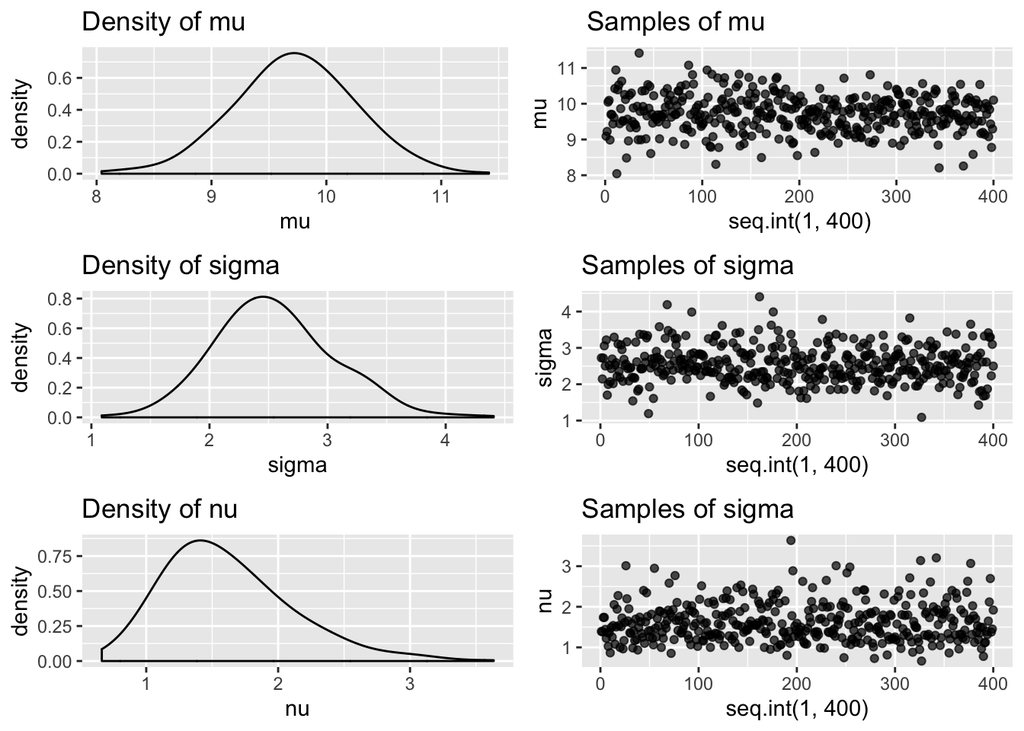

```r
samps_02 <- fit_02 %>% extract() %>% as_tibble() %>% sample_n(400)

p1 <- samps_02 %>% ggplot(aes(mu))+geom_density(bw=.2)+labs(title="Density of mu")
p2 <- samps_02 %>% ggplot(aes(x=seq.int(1,400),y=mu))+geom_point(alpha=0.7)+labs(title="Samples of mu")

p3 <- samps_02 %>% ggplot(aes(sigma))+geom_density(bw=.2)+labs(title="Density of sigma")
p4 <- samps_02 %>% ggplot(aes(x=seq.int(1,400),y=sigma))+geom_point(alpha=0.7)+labs(title="Samples of sigma")

p5 <- samps_02 %>% ggplot(aes(nu))+geom_density(bw=.2)+labs(title="Density of nu")
p6 <- samps_02 %>% ggplot(aes(x=seq.int(1,400),y=nu))+geom_point(alpha=0.7)+labs(title="Samples of sigma")

(p1 + p2)/(p3 + p4)/(p5 + p6)
```

## Comparing Paired Values

We can also compute the distribution of the differences of a paired sample.

```r
set.seed(2019)
n <- 10
mux <- 10
muy <- 12
s <- 5
z <- rnorm(n, mux, s)
y <- rnorm(n, muy, s)
x <- z-y
```

```r
model_03 <- "
data {
  int<lower=1> N;           // number of observations
  vector[N] x;              // actual data
}
parameters {
  real mu;                  // parameter sought
  real<lower=0> sigma;      // parameter sought
}
model {
  target += normal_lpdf(x | mu, sigma);     // likelihood

  target += normal_lpdf(mu | 0, 10);        // Prior
  target += uniform_lpdf(sigma | 0, 1000);  // Prior
}
"
```

```r
data_03 <- list(N = n,
             x = x)

fit_03 <- sampling(stan_model(model_code=model_03), data = data_03, chains = 2, cores = 2)
```

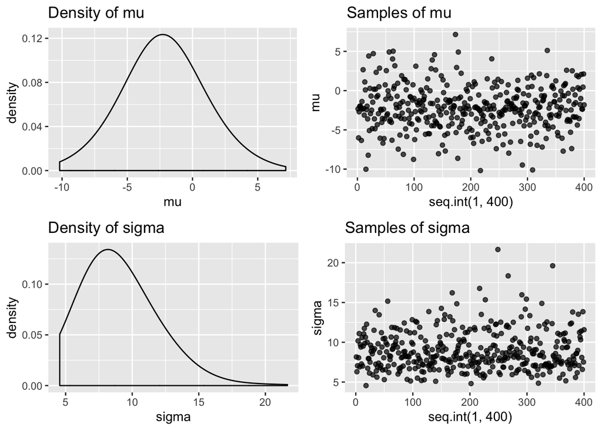

```r
samps_03 <- fit_03 %>% extract() %>% as_tibble() %>% sample_n(400)

p1 <- samps_03 %>% ggplot(aes(mu))+geom_density(bw=2)+labs(title="Density of mu")
p2 <- samps_03 %>% ggplot(aes(x=seq.int(1,400),y=mu))+geom_point(alpha=0.7)+labs(title="Samples of mu")

p3 <- samps_03 %>% ggplot(aes(sigma))+geom_density(bw=2)+labs(title="Density of sigma")
p4 <- samps_03 %>% ggplot(aes(x=seq.int(1,400),y=sigma))+geom_point(alpha=0.7)+labs(title="Samples of sigma")

(p1 + p2)/(p3 + p4)
```

## Non-Paired Comparisons

Similar to the previous example, here we generate different sets of data points. Both different in lenght and not paired. Here we introduce a new block, the transformed parameters block.

It is used to calculate new variables in our model, for which we will estimate a distribution for them.

```r
set.seed(2019)
nx <- 100
ny <- 50
mux <- 10
muy <- 12
s <- 5
x <- rnorm(nx, mux, s)
y <- rnorm(ny, muy, s)
```

```r
model_04 <- "
data {
  int<lower=1> N_x;
  int<lower=1> N_y;
  vector[N_x] x;
  vector[N_y] y;
}
parameters {
  real mu_x;
  real mu_y;
  real<lower=0> sigma_x;
  real<lower=0> sigma_y;
}
transformed parameters {
  real sigma_diff = sigma_x - sigma_y;
  real mu_diff = mu_x - mu_y;
}
model {
  target += normal_lpdf(x | mu_x, sigma_x);  // Likelihood
  target += normal_lpdf(y | mu_y, sigma_y);  // Likelihood

  target += normal_lpdf(mu_x | 10, 6);       // Prior
  target += normal_lpdf(mu_y | 10, 6);       // Prior

  target += uniform_lpdf(sigma_x | 0, 10);   // Prior
  target += uniform_lpdf(sigma_y | 0, 10);   // Prior
}
"
```

```r
data_04 <- list(N_x = nx,
             N_y = ny,
             x = x,
             y = y)

fit_04 <- sampling(stan_model(model_code=model_04),data = data_04, iter = 1000, chains = 3, cores = 3)
```

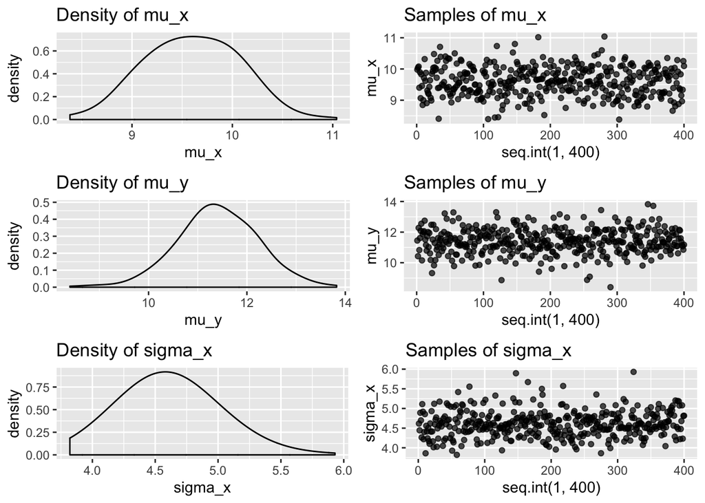

```r
samps_04 <- fit_04 %>% extract() %>% as_tibble() %>% sample_n(400)

p1 <- samps_04 %>% ggplot(aes(mu_x))+geom_density(bw=.2)+labs(title="Density of mu_x")
p2 <- samps_04 %>% ggplot(aes(x=seq.int(1,400),y=mu_x))+geom_point(alpha=0.7)+labs(title="Samples of mu_x")

p3 <- samps_04 %>% ggplot(aes(mu_y))+geom_density(bw=.3)+labs(title="Density of mu_y")
p4 <- samps_04 %>% ggplot(aes(x=seq.int(1,400),y=mu_y))+geom_point(alpha=0.7)+labs(title="Samples of mu_y")

p5 <- samps_04 %>% ggplot(aes(sigma_x))+geom_density(bw=.3)+labs(title="Density of sigma_x")
p6 <- samps_04 %>% ggplot(aes(x=seq.int(1,400),y=sigma_x))+geom_point(alpha=0.7)+labs(title="Samples of sigma_x")

p7 <- samps_04 %>% ggplot(aes(sigma_y))+geom_density(bw=.3)+labs(title="Density of sigma_y")
p8 <- samps_04 %>% ggplot(aes(x=seq.int(1,400),y=sigma_y))+geom_point(alpha=0.7)+labs(title="Samples of sigma_y")

p9 <- samps_04 %>% ggplot(aes(sigma_diff))+geom_density(bw=.3)+labs(title="Density of sigma_diff")
p10 <- samps_04 %>% ggplot(aes(x=seq.int(1,400),y=sigma_diff))+geom_point(alpha=0.7)+labs(title="Samples of sigma_diff")

p11 <- samps_04 %>% ggplot(aes(mu_diff))+geom_density(bw=.3)+labs(title="Density of mu_diff")
p12 <- samps_04 %>% ggplot(aes(x=seq.int(1,400),y=mu_diff))+geom_point(alpha=0.7)+labs(title="Samples of mu_diff")

(p1 + p2)/(p3 + p4)/(p5 + p6)
```

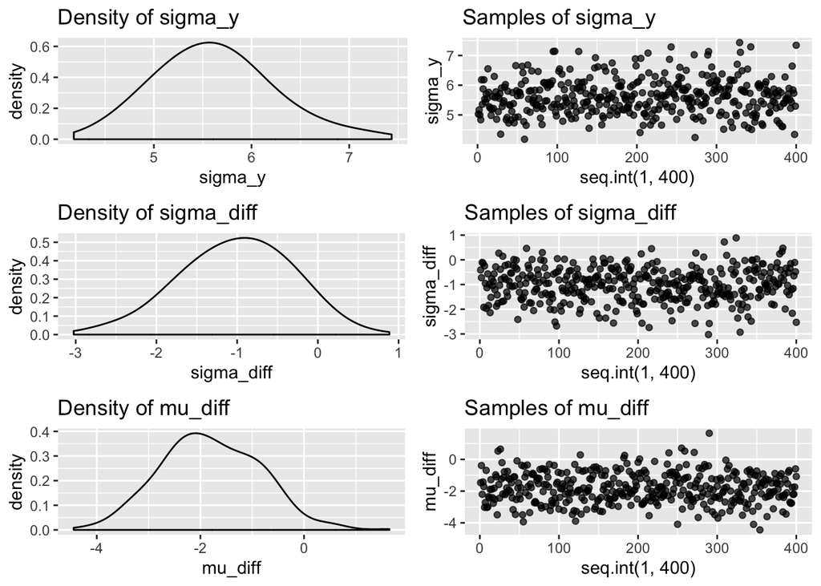

```r
(p7 + p8)/(p9 + p10)/(p11 + p12)
```

## Bayesian Regression

One way to model a bayesian regression is to provide the regression as the mean.

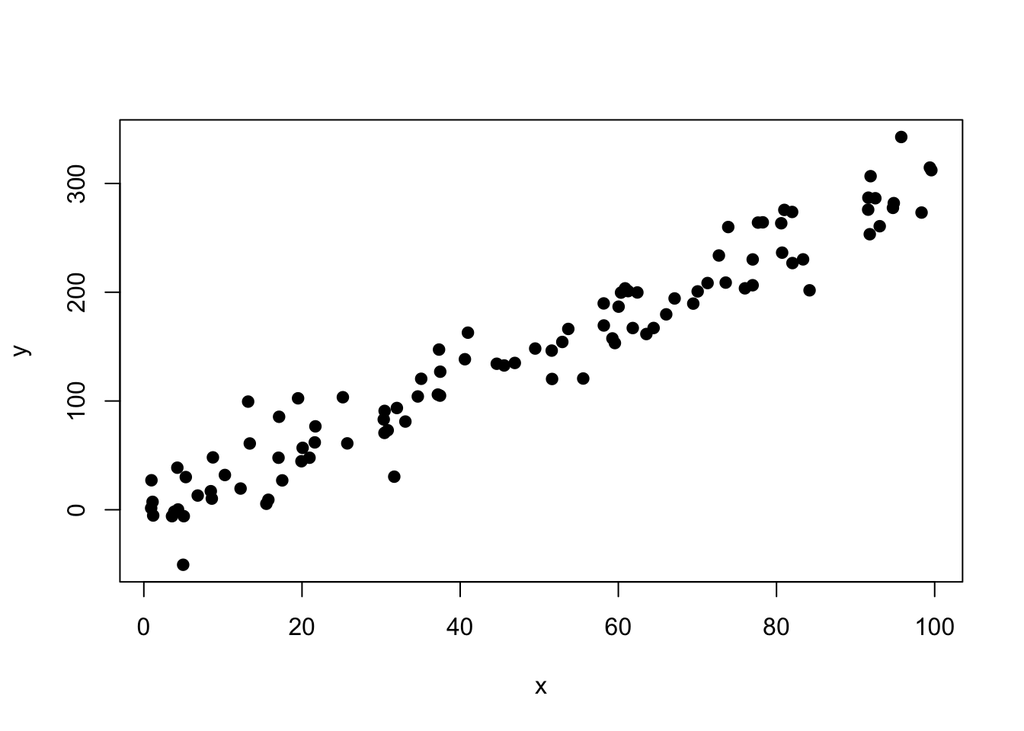

```r
set.seed(2019)
n <- 100
a <- 3
b <- 0.5
s <- 25
x <- runif(n, 0, 100)
y <- a * x + b + rnorm(n, 0, s)
plot(x, y, pch=19)
```

Here, there are multiple ways you could model it. Two simple differences, is you can either not define mu, and replace it with the regression equation `target += normal_lpdf(y | a*x + b, sigma)` or you can define mu in the model block. Here you must pass it at the begining ofthe model for it to work. You cannot define model variables lower, which means if you provide a `print()` statement (because you are checking the values of your model) in front of those variables, it’s not going to work.

```r
model_05 <- "
data {
  int<lower=1> N;       // Number of observations
  vector[N] x;          // Single feature
  vector[N] y;          // Output
}
parameters {
  real<lower=0> sigma;  // standard deviation of y
  real a;               // slope
  real b;               // y intercept
}
model {
  // print(N);          // <----- uncommenting print will throw an error

  vector[N] mu;
  mu = a * x + b;

  // print(N);          // <----- uncommenting print will work here but will print # of iterations

  target += normal_lpdf(sigma | 0, 10);   // Prior for the standard deviation of y
  target += normal_lpdf(a | 1, 10);       // Prior for the slope
  target += normal_lpdf(b | 0, 10);       // Prior for the intercept

  target += normal_lpdf(y | mu, sigma);   // Likelihood
}
"
```

```r
data_05 <- list(N = n,
             x = x,
             y = y)

fit_05 <- sampling(stan_model(model_code=model_05),data=data_05, iter = 1000, chains = 2, cores =2)
```

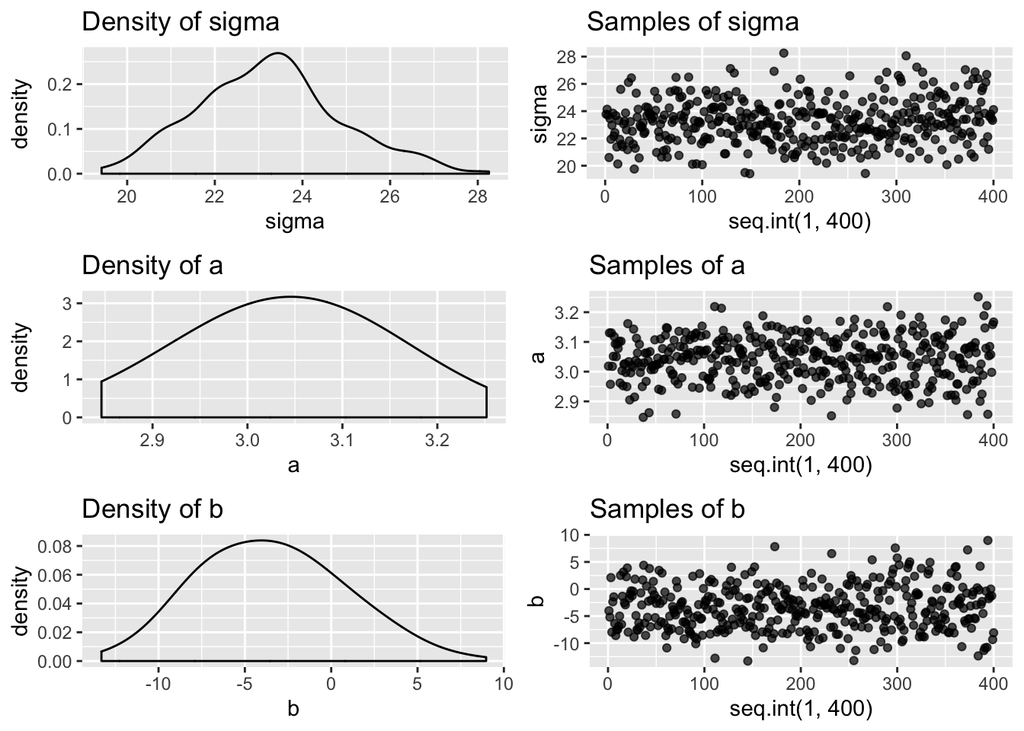

```r
samps_05 <- fit_05 %>% extract() %>% as_tibble() %>% sample_n(400)

p1 <- samps_05 %>% ggplot(aes(sigma))+geom_density(bw=.4)+labs(title="Density of sigma")
p2 <- samps_05 %>% ggplot(aes(x=seq.int(1,400),y=sigma))+geom_point(alpha=0.7)+labs(title="Samples of sigma")

p3 <- samps_05 %>% ggplot(aes(a))+geom_density(bw=.1)+labs(title="Density of a")
p4 <- samps_05 %>% ggplot(aes(x=seq.int(1,400),y=a))+geom_point(alpha=0.7)+labs(title="Samples of a")

p5 <- samps_05 %>% ggplot(aes(b))+geom_density(bw=2)+labs(title="Density of b")
p6 <- samps_05 %>% ggplot(aes(x=seq.int(1,400),y=b))+geom_point(alpha=0.7)+labs(title="Samples of b")

(p1 + p2) / (p3 + p4) / (p5 + p6)
```

Now we can use the samples generated to plot the regression lines on the original data points. All of them have a slight different slope.

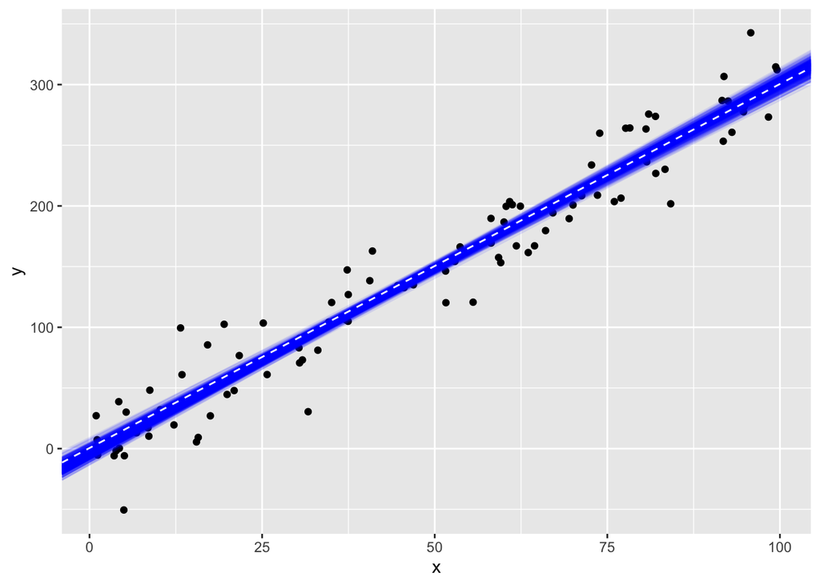

```r
a <- 3
b <- 0.5
pp <- data_05 %>% as_tibble() %>% ggplot(aes(x,y))+geom_point()+
  geom_abline(aes(intercept = b, slope = a), data = samps_05, color = 'blue', alpha = .1)+
  geom_abline(aes(intercept = b, slope = a), color = 'white', linetype = 2)

pp
```

## Hierarchical Regression

Here we will generate five groups of data which will have 5 different slopes and 5 different intercepts.

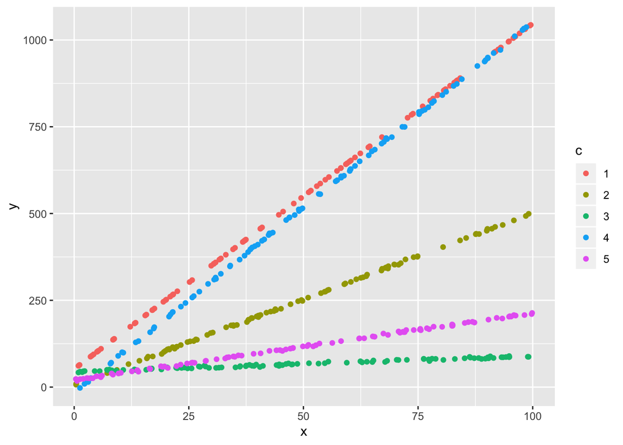

```r
set.seed(2019)
n <- 100
G <- 5

a <- rnorm(G,7,4)   # 5 different slopes
b <- rnorm(G, 30, 30)  # 5 intercept intercepts
s <- 2
x1 <- runif(n, 0, 100)# runif(n, 0, 100)  # -> why not just seq.int(1,100)
y1 <- a[1] * x1 + b[1]    # y1 = 6.77 * x -1.6 + E    -> 100 observations
f1<-rep(1,n)

x<-x1
y<-y1
f<-f1
for (j in 2:G){
  x1 <- runif(n, 0, 100)#runif(n, 0, 100)  # -> why not just seq.int(1,100)
  y1 <- a[j] * x1 + b[j] + rnorm(n, 0, s)
  f1<-rep(j,n)
  x<-c(x,x1)
  y<-c(y,y1)
  f<-c(f,f1)
}
N <- length(x)
dataList <- list( x = x, y = y, f=f, N = N, G = G)

pp <- tibble(x=x,y=y,c=f) %>% mutate(c = factor(c)) %>% ggplot(aes(x=x,y=y,color=c))+geom_point()
pp
```

Here all five slopes and five intercepts will come from a parent distribution.

A note on data types. Vectors in STAN are only used for real values. Thus, if you want to pass in integers because you will be using those as indexes, use int name_array[size_array] instead of vector[size_array] name_array.

```r
model_06 <- "
data {
  int<lower=1> N;  // Number of observations
  int<lower=1> G;  // Number of groups
  int f[N];     // Group id
  vector[N] x;
  vector[N] y;
}
parameters {
  vector[G] a;  // 5 slopes
  vector[G] b;  // 5 intercepts

  real mua;     // parent mu for slopes
  real mub;     // parent mu for intercepts

  real<lower=0> sigma;
  real<lower=0> sigmac;
}
model {
  vector[N] mu;  // We aren't having our model estimate the distribution of this variable, so we don't define it in params

  for (j in 1:G){
    target += normal_lpdf(a[j] | mua, sigmac);
    target += normal_lpdf(b[j] | mub, sigmac);
  }

  for (i in 1:N){
    mu[i] = a[f[i]]*x[i]+b[f[i]];  // use slope and intercept value using the reference f[i] {1,2,3,4,5}
    target += normal_lpdf(y[i] | mu[i], sigma);
  }

  target += normal_lpdf(mua | 0, 10);
  target += normal_lpdf(mub | 0, 10);
  target += uniform_lpdf(sigma | 0, 1000);
  target += uniform_lpdf(sigmac | 0, 1000);
}
"
```

```r
data_06 <- list(x = x, y = y, f=f, N = N, G = G)
fit_06 <- sampling(stan_model(model_code=model_06),data=data_06, iter = 1000, chains = 2, cores =2)
```

```r
print(fit_06)
```

```
## Inference for Stan model: bb5f6bbfbe2dffa6a6717eee79bfcf35.
## 2 chains, each with iter=1000; warmup=500; thin=1;
## post-warmup draws per chain=500, total post-warmup draws=1000.
##
##            mean se_mean   sd     2.5%      25%      50%      75%    97.5%
## a[1]       9.95    0.00 0.01     9.94     9.95     9.95     9.96     9.97
## a[2]       4.96    0.00 0.01     4.94     4.95     4.96     4.96     4.97
## a[3]       0.45    0.00 0.01     0.44     0.45     0.45     0.46     0.46
## a[4]      10.67    0.00 0.01    10.66    10.67    10.67    10.67    10.68
## a[5]       1.93    0.00 0.01     1.92     1.92     1.93     1.93     1.94
## b[1]      52.12    0.01 0.33    51.49    51.89    52.12    52.35    52.76
## b[2]       5.43    0.01 0.37     4.72     5.18     5.43     5.68     6.13
## b[3]      44.24    0.01 0.34    43.61    44.02    44.24    44.48    44.91
## b[4]     -15.06    0.01 0.37   -15.77   -15.31   -15.08   -14.82   -14.35
## b[5]      20.28    0.01 0.34    19.62    20.06    20.26    20.51    20.96
## mua        2.79    0.22 7.16   -12.30    -2.00     2.94     7.39    17.31
## mub       10.18    0.26 7.49    -5.54     4.96    10.60    15.28    24.03
## sigma      1.78    0.00 0.06     1.67     1.73     1.77     1.81     1.90
## sigmac    24.03    0.28 6.90    14.60    19.24    22.76    27.45    41.37
## lp__   -1057.30    0.15 2.80 -1063.70 -1058.72 -1057.01 -1055.34 -1053.00
##        n_eff Rhat
## a[1]     866    1
## a[2]     943    1
## a[3]     919    1
## a[4]     805    1
## a[5]    1175    1
## b[1]     787    1
## b[2]     915    1
## b[3]     910    1
## b[4]     855    1
## b[5]    1077    1
## mua     1088    1
## mub      832    1
## sigma   1372    1
## sigmac   609    1
## lp__     340    1
##
## Samples were drawn using NUTS(diag_e) at Thu Aug 29 12:21:37 2019.
## For each parameter, n_eff is a crude measure of effective sample size,
## and Rhat is the potential scale reduction factor on split chains (at
## convergence, Rhat=1).
```

## Three level hiarchical model

Here you could see it as having a country with a distribution. Within that country, having provinces drawing a distribution from it’s country. Then cities within that provinces distribution.

This is usefull, because a business that isn’t part of your province, could simply draw it’s data from the nationals distribution.

```r
set.seed(2020)
canada_mu <- 50
canada_mu_sigma <- 6

canada_sd <- 15
canada_sd_sigma <- 3

sigma <- 3

ontario_mu <- rnorm(1,canada_mu,canada_mu_sigma)
ontario_mu_sigma <- 7
ontario_sd <- rnorm(1,canada_sd,canada_sd_sigma)
ontario_sd_sigma <- 1

quebec_mu <- rnorm(1,canada_mu,canada_mu_sigma)
quebec_mu_sigma <- 2
quebec_sd <- rnorm(1,canada_sd,canada_sd_sigma)
quebec_sd_sigma <- 4

toronto_mu <- rnorm(1,ontario_mu,ontario_mu_sigma)
toronto_sd <- rnorm(1,ontario_sd,ontario_sd_sigma)

montreal_mu <- rnorm(1,quebec_mu,quebec_mu_sigma)
montreal_sd <- rnorm(1,quebec_sd,quebec_sd_sigma)

business_1_mu <- rnorm(1,montreal_mu,2)
business_1_sd <- rnorm(1,montreal_sd,2)

business_2_mu <- rnorm(1,toronto_mu,2)
business_2_sd <- rnorm(1,toronto_sd,2)

# business 1
b1 <- c()
for (i in 1:10){
  a <- rnorm(1,business_1_mu,business_1_sd)
  value <- a * i + 300
  print(value)
  b1[i] <- value
}
```

```
## [1] 361.8799
## [1] 389.4969
## [1] 442.3849
## [1] 573.9026
## [1] 637.1312
## [1] 393.6409
## [1] 466.5931
## [1] 695.5631
## [1] 953.0894
## [1] 908.0711
```

```r
# business 2
b2 <- c()
for (i in 1:10){
  a <- rnorm(1,business_1_mu,business_1_sd)
  value <- a * i + 20
  print(a)
  b2[i] <- value
}
```

```
## [1] 52.28524
## [1] 48.00916
## [1] 57.92359
## [1] 50.97992
## [1] 62.98859
## [1] 59.04295
## [1] 47.19751
## [1] 50.01495
## [1] 39.93094
## [1] 40.68267
```

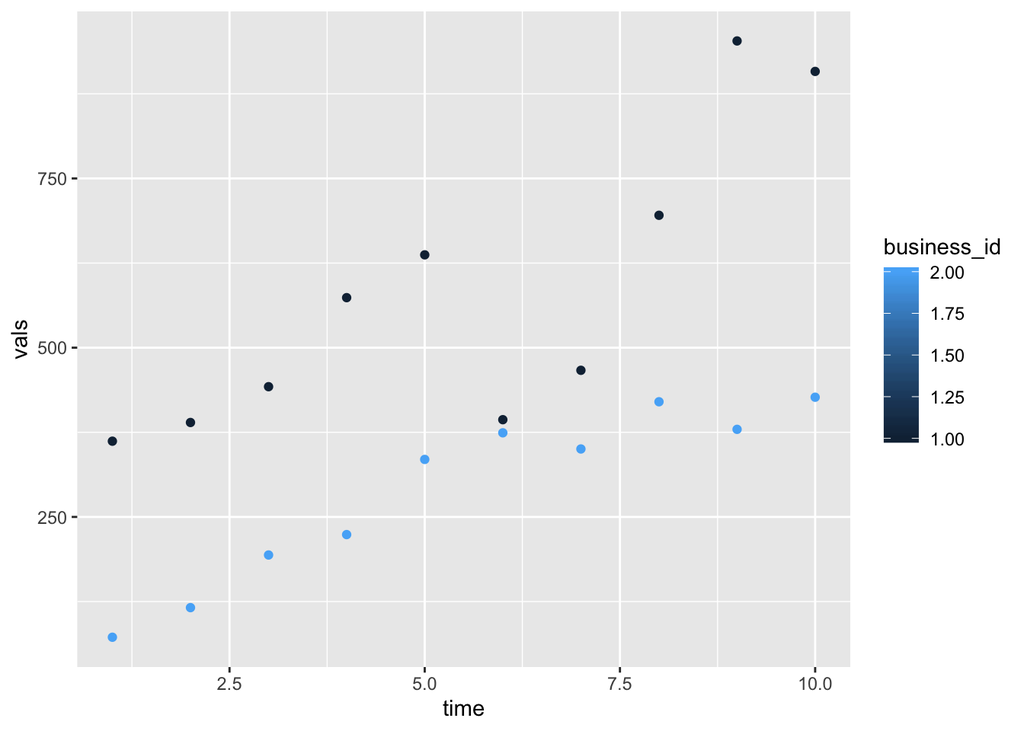

```r
b_ <- tibble(time = rep(c(1,2,3,4,5,6,7,8,9,10),2),
             vals = c(b1, b2),
             business_id = c(rep(1,10),rep(2,10)),
             prov_id = c(rep(1,10),rep(2,10)),
             city_id = c(rep(1,10),rep(2,10)))

ggplot(b_,aes(x=time,y=vals,color=business_id))+geom_point()
```

```r
model_recent <- "
data {
  // important for looping
  int<lower=0> Nb;  // # of observations total (individual businesses)
  int<lower=0> Nc;  // # of groups (cities) 2
  int<lower=0> Np;  // # of groups (provinces)

  // int<lower=1> business_id[Nb];   // not sure about this one ?

  int<lower=1> city_id[Nb];
  int<lower=1> province_id[Nb];     // City province lookup

  int<lower=1> city_province_lkp[Nc];

  real y[Nb];
  real x[Nb];
}
parameters {
  real<lower=0> sigma;

  real canada_mu;           // Canada
  real<lower=0> canada_sigma;        // Canada

  // Varying intercepts and slopes
  real beta_0cp[Nc];
  real a_0cp[Nc];

  //
  real prov_mu_beta[Np];
  real<lower=0> prov_s_beta[Np];

  real prov_mu_slope[Np];
  real<lower=0> prov_s_slope[Np];

}
transformed parameters {

  //real mu[Nb];

  //for (b in 1:Nb){
  //  mu[b] = a_0cp[city_id[b]] * x[b] + beta_0cp[city_id[b]];  // mu of a business will be slope from city + x position + intercept from city
  //}


}
model {
  real mu[Nb];

  // Level-3 (level-3 random intercepts)
  for (p in 1:Np){

    target += normal_lpdf(prov_mu_beta[p] | canada_mu, canada_sigma);
    target += normal_lpdf(prov_s_beta[p] | canada_mu, canada_sigma);

    target += normal_lpdf(prov_mu_slope[p] | canada_mu, canada_sigma);
    target += normal_lpdf(prov_s_slope[p] | canada_mu, canada_sigma);

  }

  // Level-2 (level-2 random intercepts)
  for (c in 1:Nc){
    target += normal_lpdf(beta_0cp[c] | prov_mu_beta[city_province_lkp[c]], prov_s_beta[city_province_lkp[c]]);
    target += normal_lpdf(a_0cp[c] | prov_mu_slope[city_province_lkp[c]], prov_s_slope[city_province_lkp[c]]);
  }

  for (b in 1:Nb) {
    mu[b] = a_0cp[city_id[b]] * x[b] + beta_0cp[city_id[b]];  // mu of a business will be slope from city + x position + intercept from city

    target += normal_lpdf(y[b] | mu[b], sigma);
  }

}
"
```

```r
data <- with(b_,
             list(x    = time,
                  y    = vals,
                  Nb   = 20,                  # Number of observations
                  Nc   = 2,                   # Number of cities
                  Np   = 2,                   # Number of provinces
                  business_id = business_id,  # business reference (vector)
                  city_id = city_id,          # city reference (vector)
                  province_id = prov_id,       # province reference (vector)
                  city_province_lkp = c(1,2)
                  ))
```

```r
fit <- sampling(stan_model(model_code = model_recent),data=data,iter=2000,chains=4,cores=2)
```

```
## 'pars' not specified. Showing first 10 parameters by default.
```

```
## ci_level: 0.8 (80% intervals)
```

```
## outer_level: 0.95 (95% intervals)
```

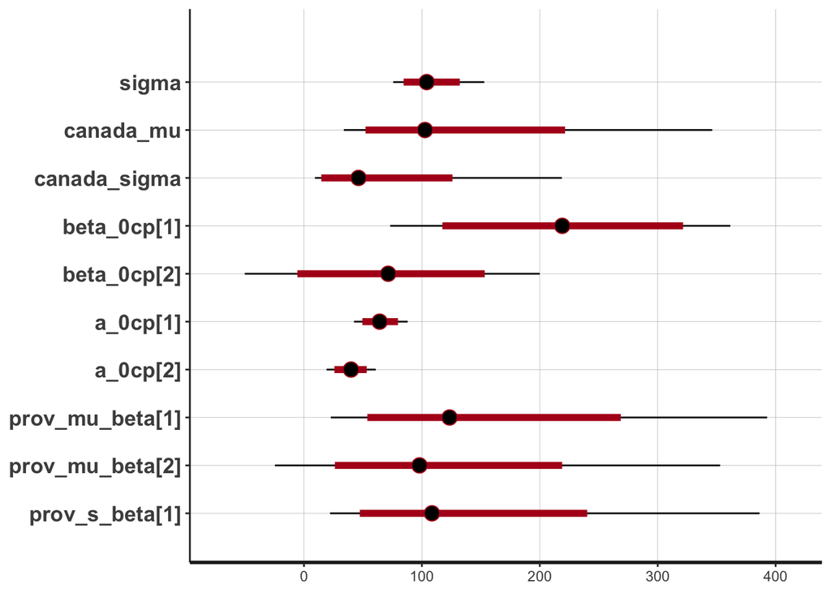

```r
plot(fit)
```

As I develop better knowledge on Bayesian Statistics and Stan, I will add the resources here.